# Adaptive Crop Yield Forecasting Using Statistical Learning Algorithms - team003

Vamsi Sai Garapati, Vaishak Muralidharan, Kaushal Shivaprakashan

```r
library(ISLR2)
library(ggplot2)
```

# Loading Data

```r
crop_data <- read.csv("crop_yield_trimmed.csv")
```

- (b). [2 pts] Inspect the first few rows of the dataset using `head()` and check the structure of the data using `str()`. Check for any missing values using `is.na()`.

**Exploratory data analysis and data preprocessing**

```r
head(crop_data,5)
```

```
##   Region Soil_Type    Crop Rainfall_mm Temperature_Celsius Fertilizer_Used
## 1   West     Sandy  Cotton    897.0772            27.67697           False
## 2  South      Clay    Rice    992.6733            18.02614            True
## 3  North      Loam  Barley    147.9980            29.79404           False
## 4  North     Sandy Soybean    986.8663            16.64419           False
## 5  South      Silt   Wheat    730.3792            31.62069            True
##   Irrigation_Used Weather_Condition Days_to_Harvest Yield_tons_per_hectare
## 1            True            Cloudy             122               6.555816
## 2            True             Rainy             140               8.527341
## 3           False             Sunny             106               1.127443
## 4            True             Rainy             146               6.517573
## 5            True            Cloudy             110               7.248251
```

```r
orig_crop_data<-crop_data
str(crop_data)
```

```
## 'data.frame':    150000 obs. of  10 variables:
##  $ Region                : chr  "West" "South" "North" "North" ...
##  $ Soil_Type             : chr  "Sandy" "Clay" "Loam" "Sandy" ...
##  $ Crop                  : chr  "Cotton" "Rice" "Barley" "Soybean" ...
##  $ Rainfall_mm           : num  897 993 148 987 730 ...
##  $ Temperature_Celsius   : num  27.7 18 29.8 16.6 31.6 ...
##  $ Fertilizer_Used       : chr  "False" "True" "False" "False" ...
##  $ Irrigation_Used       : chr  "True" "True" "False" "True" ...
##  $ Weather_Condition     : chr  "Cloudy" "Rainy" "Sunny" "Rainy" ...
##  $ Days_to_Harvest       : int  122 140 106 146 110 74 90 61 127 140 ...
##  $ Yield_tons_per_hectare: num  6.56 8.53 1.13 6.52 7.25 ...
```

```r
colSums(is.na(crop_data))
```

```
##                 Region              Soil_Type                   Crop
##                      0                      0                      0
##            Rainfall_mm    Temperature_Celsius        Fertilizer_Used
##                      0                      0                      0
##        Irrigation_Used      Weather_Condition        Days_to_Harvest
##                      0                      0                      0
## Yield_tons_per_hectare
##                      0
```

```r
summary(crop_data)
```

```
##     Region           Soil_Type             Crop            Rainfall_mm
##  Length:150000      Length:150000      Length:150000      Min.   : 100.0
##  Class :character   Class :character   Class :character   1st Qu.: 324.3
##  Mode  :character   Mode  :character   Mode  :character   Median : 549.9
##                                                           Mean   : 549.4
##                                                           3rd Qu.: 773.2
##                                                           Max.   :1000.0
##  Temperature_Celsius Fertilizer_Used    Irrigation_Used    Weather_Condition
##  Min.   :15.00       Length:150000      Length:150000      Length:150000
##  1st Qu.:21.25       Class :character   Class :character   Class :character
##  Median :27.54       Mode  :character   Mode  :character   Mode  :character
##  Mean   :27.50
##  3rd Qu.:33.75
##  Max.   :40.00
##  Days_to_Harvest Yield_tons_per_hectare
##  Min.   : 60.0   Min.   :-0.8416
##  1st Qu.: 82.0   1st Qu.: 3.4181
##  Median :104.0   Median : 4.6520
##  Mean   :104.4   Mean   : 4.6473
##  3rd Qu.:127.0   3rd Qu.: 5.8719
##  Max.   :149.0   Max.   : 9.7270
```

```r
colnames(crop_data)
```

```
##  [1] "Region"                 "Soil_Type"              "Crop"
##  [4] "Rainfall_mm"            "Temperature_Celsius"    "Fertilizer_Used"
##  [7] "Irrigation_Used"        "Weather_Condition"      "Days_to_Harvest"
## [10] "Yield_tons_per_hectare"
```

The following are observations from the summary provided:

General Observations: 1. Categorical Variables: • There are several categorical variables, including Region, Soil_Type, Crop, Fertilizer_Used, Irrigation_Used, and Weather_Condition. • Each variable has 150,000 entries, indicating no missing data across these columns. 2. Numerical Variables: • Rainfall_mm, Temperature_Celsius, Days_to_Harvest, and Yield_tons_per_hectare are numerical variables. • No obvious missing values are found within these variables, since all 150,000 observations are presented in the summary.

Specific Observations:

Rainfall (Rainfall_mm):

• From 100.0 mm to 1,000.0 mm. • Median rainfall is 549.9 mm, with the mean very close at 549.4 mm, suggesting symmetry in the distribution.

Temperature (Temperature_Celsius):

Days to Harvest:

Yield (Yield_tons_per_hectare): • Ranges from -0.8416 to 9.7270 tons per hectare. • The minimum value is negative, which is unusual and might suggest either an outlier or data error. • Median yield is 4.6520 tons/hectare with an average of 4.6473 tons/hectare; hence, yield data seems to be symmetric. • Interquartile range (IQR) for yield ranges from 3.4181 to 5.8719 tons per hectare.

```r
cols_to_encode <- c("Region", "Soil_Type", "Crop", "Weather_Condition")
for (col in cols_to_encode) {
  crop_data[[col]] <- as.factor(crop_data[[col]])
  dummy_vars <- model.matrix(as.formula(paste0("~ ", col, " + 0")), data = crop_data)
  crop_data <- cbind(crop_data, dummy_vars)
  crop_data[[col]] <- NULL
}
head(crop_data, 5)
```

```
##   Rainfall_mm Temperature_Celsius Fertilizer_Used Irrigation_Used
## 1    897.0772            27.67697           False            True
## 2    992.6733            18.02614            True            True
## 3    147.9980            29.79404           False           False
## 4    986.8663            16.64419           False            True
## 5    730.3792            31.62069            True            True
##   Days_to_Harvest Yield_tons_per_hectare RegionEast RegionNorth RegionSouth
## 1             122               6.555816          0           0           0
## 2             140               8.527341          0           0           1
## 3             106               1.127443          0           1           0
## 4             146               6.517573          0           1           0
## 5             110               7.248251          0           0           1
##   RegionWest Soil_TypeChalky Soil_TypeClay Soil_TypeLoam Soil_TypePeaty
## 1          1               0             0             0              0
## 2          0               0             1             0              0
```

[output cut: 21 more lines]

```r
bool_cols <- c("Fertilizer_Used", "Irrigation_Used")
for (col in bool_cols) {
  crop_data[[col]] <- as.numeric(crop_data[[col]] == "TRUE")
}

head(crop_data, 5)
```

```
##   Rainfall_mm Temperature_Celsius Fertilizer_Used Irrigation_Used
## 1    897.0772            27.67697               0               0
## 2    992.6733            18.02614               0               0
## 3    147.9980            29.79404               0               0
## 4    986.8663            16.64419               0               0
## 5    730.3792            31.62069               0               0
##   Days_to_Harvest Yield_tons_per_hectare RegionEast RegionNorth RegionSouth
## 1             122               6.555816          0           0           0
## 2             140               8.527341          0           0           1
## 3             106               1.127443          0           1           0
## 4             146               6.517573          0           1           0
## 5             110               7.248251          0           0           1
##   RegionWest Soil_TypeChalky Soil_TypeClay Soil_TypeLoam Soil_TypePeaty
## 1          1               0             0             0              0
## 2          0               0             1             0              0
```

[output cut: 21 more lines]

```r
before_count <- nrow(crop_data)
crop_data <- crop_data[!apply(crop_data, 1, function(row) any(is.na(row) | row == "")), ]
after_count <- nrow(crop_data)

cat("Row count before removing missing values:", before_count, "\n")
```

```
## Row count before removing missing values: 150000
```

```r
cat("Row count after removing missing values:", after_count, "\n")
```

```
## Row count after removing missing values: 150000
```

```r
colnames(crop_data)
```

```
##  [1] "Rainfall_mm"             "Temperature_Celsius"
##  [3] "Fertilizer_Used"         "Irrigation_Used"
##  [5] "Days_to_Harvest"         "Yield_tons_per_hectare"
##  [7] "RegionEast"              "RegionNorth"
##  [9] "RegionSouth"             "RegionWest"
## [11] "Soil_TypeChalky"         "Soil_TypeClay"
## [13] "Soil_TypeLoam"           "Soil_TypePeaty"
## [15] "Soil_TypeSandy"          "Soil_TypeSilt"
## [17] "CropBarley"              "CropCotton"
## [19] "CropMaize"               "CropRice"
## [21] "CropSoybean"             "CropWheat"
## [23] "Weather_ConditionCloudy" "Weather_ConditionRainy"
## [25] "Weather_ConditionSunny"
```

```r
colnames(crop_data[,1:10])
```

```
##  [1] "Rainfall_mm"            "Temperature_Celsius"    "Fertilizer_Used"
##  [4] "Irrigation_Used"        "Days_to_Harvest"        "Yield_tons_per_hectare"
##  [7] "RegionEast"             "RegionNorth"            "RegionSouth"
## [10] "RegionWest"
```

[figure not shown]

```r
# Load necessary libraries
library(ggplot2)

# Boxplot: Yield vs Region
ggplot(crop_data, aes(x = factor(RegionEast + RegionNorth + RegionSouth + RegionWest), y = Yield_tons_per_hectare)) +
  geom_boxplot() +
  labs(title = "Yield vs Region", x = "Region", y = "Yield (tons per hectare)")
```

[figure not shown]

```r
# Boxplot: Yield vs Soil_Type
ggplot(crop_data, aes(x = factor(Soil_TypeChalky + Soil_TypeClay + Soil_TypeLoam + Soil_TypePeaty + Soil_TypeSandy + Soil_TypeSilt),
                 y = Yield_tons_per_hectare)) +
  geom_boxplot() +
  labs(title = "Yield vs Soil Type", x = "Soil Type", y = "Yield (tons per hectare)")
```

[figure not shown]

```r
# Boxplot: Yield vs Crop
ggplot(crop_data, aes(x = factor(CropBarley + CropCotton + CropMaize + CropRice + CropSoybean + CropWheat),
                 y = Yield_tons_per_hectare)) +
  geom_boxplot() +
  labs(title = "Yield vs Crop", x = "Crop Type", y = "Yield (tons per hectare)")
```

```r
colnames(crop_data)
```

```
##  [1] "Rainfall_mm"             "Temperature_Celsius"
##  [3] "Fertilizer_Used"         "Irrigation_Used"
##  [5] "Days_to_Harvest"         "Yield_tons_per_hectare"
##  [7] "RegionEast"              "RegionNorth"
##  [9] "RegionSouth"             "RegionWest"
## [11] "Soil_TypeChalky"         "Soil_TypeClay"
## [13] "Soil_TypeLoam"           "Soil_TypePeaty"
## [15] "Soil_TypeSandy"          "Soil_TypeSilt"
## [17] "CropBarley"              "CropCotton"
## [19] "CropMaize"               "CropRice"
## [21] "CropSoybean"             "CropWheat"
## [23] "Weather_ConditionCloudy" "Weather_ConditionRainy"
## [25] "Weather_ConditionSunny"
```

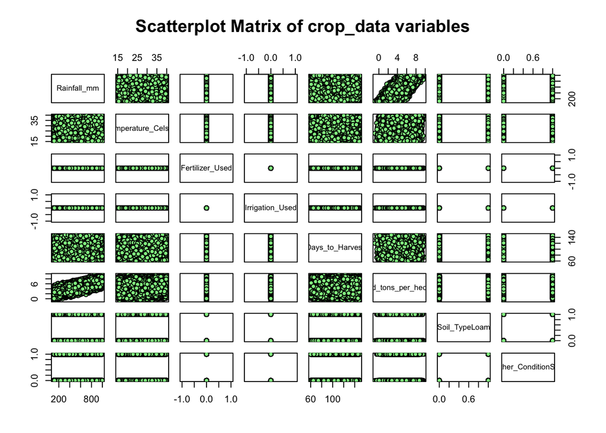

```r
selected_columns <- crop_data[, c("Rainfall_mm", "Temperature_Celsius",
                                  "Fertilizer_Used", "Irrigation_Used",
                                  "Days_to_Harvest", "Yield_tons_per_hectare",
                                  "Soil_TypeLoam", "Weather_ConditionSunny")]

pairs(selected_columns,
     main = "Scatterplot Matrix of crop_data variables",
      pch = 21, bg = "lightgreen")
```

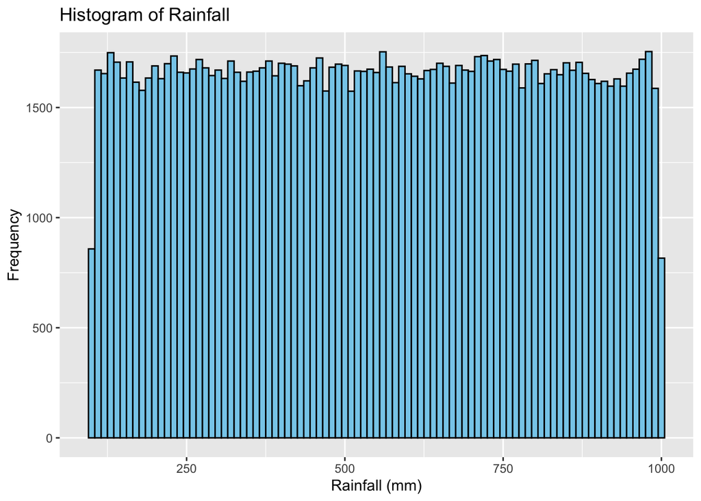

```r
#Assuming variables are loaded into MATLAB as vectors

# Load necessary library
library(ggplot2)

# Histogram: Rainfall
ggplot(crop_data, aes(x = Rainfall_mm)) +
  geom_histogram(binwidth = 10, fill = "skyblue", color = "black") +
  labs(title = "Histogram of Rainfall", x = "Rainfall (mm)", y = "Frequency")
```

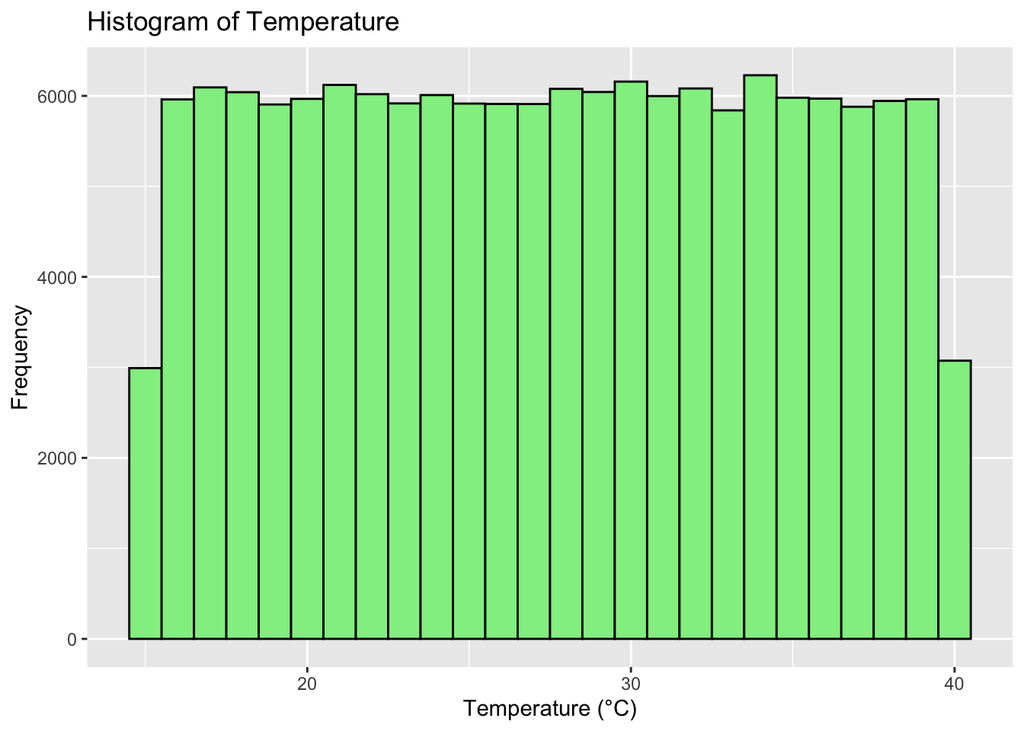

```r
# Histogram: Temperature
ggplot(crop_data, aes(x = Temperature_Celsius)) +
  geom_histogram(binwidth = 1, fill = "lightgreen", color = "black") +
  labs(title = "Histogram of Temperature", x = "Temperature (°C)", y = "Frequency")
```

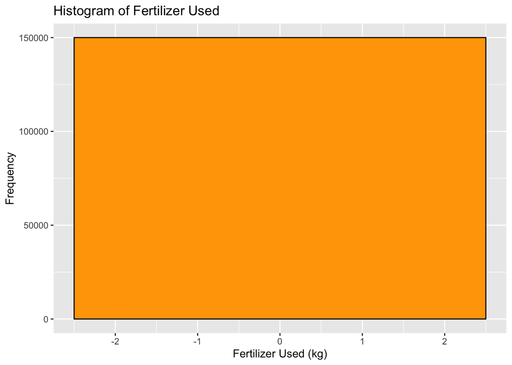

```r
# Histogram: Fertilizer Used
ggplot(crop_data, aes(x = Fertilizer_Used)) +
  geom_histogram(binwidth = 5, fill = "orange", color = "black") +
  labs(title = "Histogram of Fertilizer Used", x = "Fertilizer Used (kg)", y = "Frequency")
```

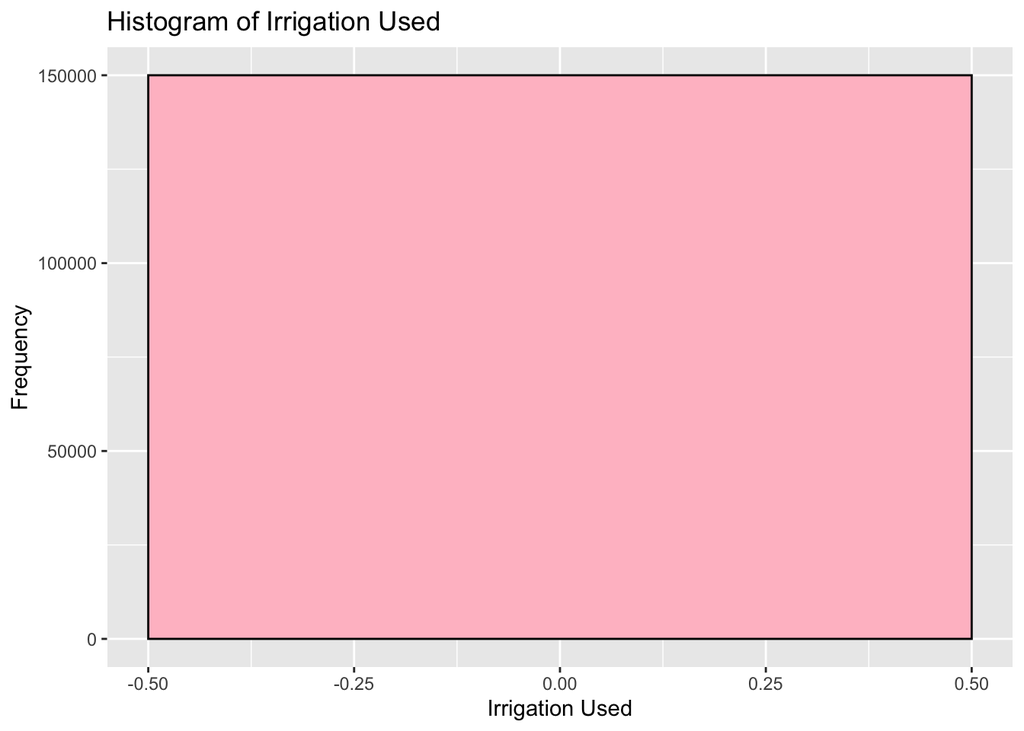

```r
# Histogram: Irrigation Used
ggplot(crop_data, aes(x = Irrigation_Used)) +
  geom_histogram(binwidth = 1, fill = "pink", color = "black") +
  labs(title = "Histogram of Irrigation Used", x = "Irrigation Used", y = "Frequency")
```

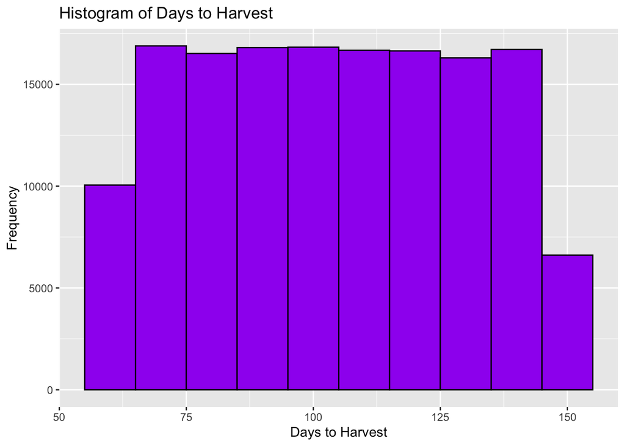

```r
# Histogram: Days to Harvest
ggplot(crop_data, aes(x = Days_to_Harvest)) +
  geom_histogram(binwidth = 10, fill = "purple", color = "black") +
  labs(title = "Histogram of Days to Harvest", x = "Days to Harvest", y = "Frequency")
```

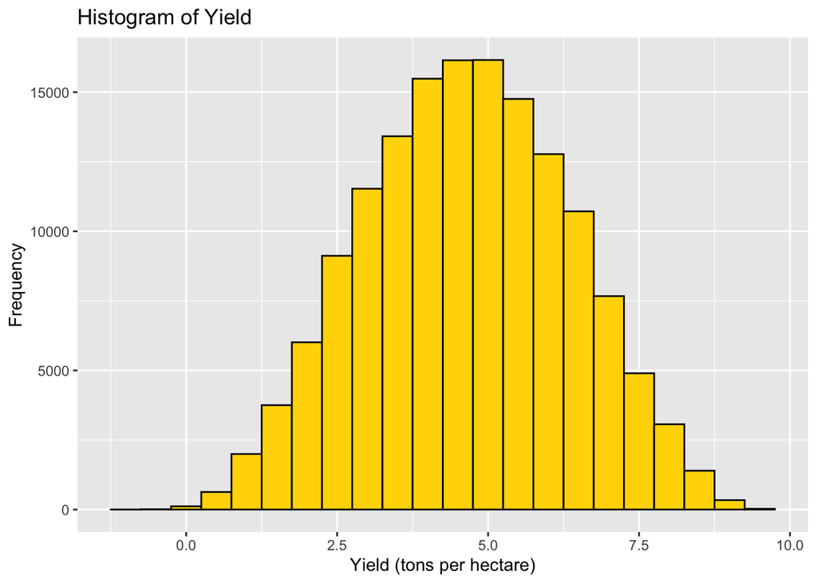

```r
# Histogram: Yield (Predictor)
ggplot(crop_data, aes(x = Yield_tons_per_hectare)) +
  geom_histogram(binwidth = 0.5, fill = "gold", color = "black") +
  labs(title = "Histogram of Yield", x = "Yield (tons per hectare)", y = "Frequency")
```

# Understanding data more

```r
# Select numeric columns for correlation analysis
numeric_cols <- crop_data[c("Rainfall_mm", "Temperature_Celsius", "Fertilizer_Used",
                            "Irrigation_Used", "Days_to_Harvest", "Yield_tons_per_hectare")]

# Compute the correlation matrix
cor_matrix <- cor(numeric_cols, use = "complete.obs")
# Print the correlation matrix
print(cor_matrix)
```

```
##                         Rainfall_mm Temperature_Celsius Fertilizer_Used
## Rainfall_mm             1.000000000        -0.002784199              NA
## Temperature_Celsius    -0.002784199         1.000000000              NA
## Fertilizer_Used                  NA                  NA               1
## Irrigation_Used                  NA                  NA              NA
## Days_to_Harvest        -0.001082961         0.003022011              NA
## Yield_tons_per_hectare  0.763474415         0.085222387              NA
##                        Irrigation_Used Days_to_Harvest Yield_tons_per_hectare
## Rainfall_mm                         NA   -0.0010829608           0.7634744151
## Temperature_Celsius                 NA    0.0030220108           0.0852223866
## Fertilizer_Used                     NA              NA                     NA
## Irrigation_Used                      1              NA                     NA
## Days_to_Harvest                     NA    1.0000000000           0.0003531314
## Yield_tons_per_hectare              NA    0.0003531314           1.0000000000
```

Observations

Rainfall and Yield (0.763):

There is a strong positive correlation between Rainfall and Yield_tons_per_hectare with a value of 0.763. This explains that rainfall is an essential determinant of crop yield. Temperature and Yield (0.085):

Temperature correlates positively with Yield_tons_per_hectare by 0.085, which is a weak relation. This may indicate that temperature has a minor impact on crop yield directly. Days to Harvest and Yield (0.00035):

Days_to_Harvest is extremely weakly positively correlated to Yield_tons_per_hectare, with values close to zero. That would hint that harvest duration probably doesn’t directly influence yield. Rainfall and Temperature (-0.0028):

There is a negligible negative correlation between Rainfall_mm and Temperature_Celsius. The two factors are almost independent in this data set. Missing Correlations:

The correlation coefficients for Fertilizer_Used and Irrigation_Used are not available (NA), likely due to the insufficient data or constancy of these columns in this dataset. That could be an area of further investigation or application of imputation techniques.  
Multicollinearity:

There are no strong correlations between the predictors, Rainfall_mm, Temperature_Celsius, Days_to_Harvest. It appears there is no multicollinearity issue regarding these variables.

# Building initial models and comparision

```r
# Fit a model using all numeric columns
model_all <- lm(Yield_tons_per_hectare ~ ., data = crop_data)
summary(model_all)
```

```
##
## Call:
## lm(formula = Yield_tons_per_hectare ~ ., data = crop_data)
##
## Residuals:
##     Min      1Q  Median      3Q     Max
## -3.4306 -0.7919  0.0004  0.7936  3.2758
##
## Coefficients: (6 not defined because of singularities)
##                           Estimate Std. Error t value Pr(>|t|)
## (Intercept)              1.338e+00  2.006e-02  66.700   <2e-16 ***
## Rainfall_mm              4.988e-03  1.079e-05 462.196   <2e-16 ***
## Temperature_Celsius      2.053e-02  3.883e-04  52.860   <2e-16 ***
## Fertilizer_Used                 NA         NA      NA       NA
## Irrigation_Used                 NA         NA      NA       NA
## Days_to_Harvest          6.002e-05  1.079e-04   0.556   0.5779
## RegionEast              -6.198e-03  7.920e-03  -0.783   0.4339
## RegionNorth             -1.423e-02  7.921e-03  -1.797   0.0723 .
## RegionSouth             -7.486e-03  7.937e-03  -0.943   0.3456
## RegionWest                      NA         NA      NA       NA
## Soil_TypeChalky         -3.425e-03  9.704e-03  -0.353   0.7241
## Soil_TypeClay            1.012e-02  9.691e-03   1.045   0.2963
## Soil_TypeLoam            5.070e-03  9.707e-03   0.522   0.6015
## Soil_TypePeaty           3.354e-03  9.696e-03   0.346   0.7294
## Soil_TypeSandy           3.865e-04  9.696e-03   0.040   0.9682
## Soil_TypeSilt                   NA         NA      NA       NA
## CropBarley               4.424e-03  9.722e-03   0.455   0.6491
## CropCotton               1.680e-03  9.694e-03   0.173   0.8624
## CropMaize                2.446e-03  9.691e-03   0.252   0.8007
## CropRice                 3.226e-03  9.705e-03   0.332   0.7396
## CropSoybean             -3.816e-03  9.692e-03  -0.394   0.6937
## CropWheat                       NA         NA      NA       NA
## Weather_ConditionCloudy  4.420e-03  6.862e-03   0.644   0.5195
## Weather_ConditionRainy  -2.074e-03  6.858e-03  -0.302   0.7623
## Weather_ConditionSunny          NA         NA      NA       NA
## ---
## Signif. codes:  0 '***' 0.001 '**' 0.01 '*' 0.05 '.' 0.1 ' ' 1
##
## Residual standard error: 1.085 on 149981 degrees of freedom
## Multiple R-squared:  0.5905, Adjusted R-squared:  0.5905
## F-statistic: 1.202e+04 on 18 and 149981 DF,  p-value: < 2.2e-16
```

```r
# Model with a subset of important variables
model_important <- lm(Yield_tons_per_hectare ~ Rainfall_mm + Temperature_Celsius + Days_to_Harvest, data = crop_data)
summary(model_important)
```

```
##
## Call:
## lm(formula = Yield_tons_per_hectare ~ Rainfall_mm + Temperature_Celsius +
##     Days_to_Harvest, data = crop_data)
##
## Residuals:
##     Min      1Q  Median      3Q     Max
## -3.4348 -0.7913  0.0003  0.7934  3.2778
##
## Coefficients:
##                      Estimate Std. Error t value Pr(>|t|)
## (Intercept)         1.336e+00  1.684e-02  79.339   <2e-16 ***
## Rainfall_mm         4.988e-03  1.079e-05 462.229   <2e-16 ***
## Temperature_Celsius 2.053e-02  3.883e-04  52.865   <2e-16 ***
## Days_to_Harvest     5.981e-05  1.079e-04   0.555    0.579
## ---
## Signif. codes:  0 '***' 0.001 '**' 0.01 '*' 0.05 '.' 0.1 ' ' 1
##
## Residual standard error: 1.085 on 149996 degrees of freedom
## Multiple R-squared:  0.5905, Adjusted R-squared:  0.5905
## F-statistic: 7.211e+04 on 3 and 149996 DF,  p-value: < 2.2e-16
```

```r
# Model with squared transformations
model_squared <- lm(Yield_tons_per_hectare ~ I(Rainfall_mm^2) + I(Temperature_Celsius^2) + Days_to_Harvest, data = crop_data)
summary(model_squared)
```

```
##
## Call:
## lm(formula = Yield_tons_per_hectare ~ I(Rainfall_mm^2) + I(Temperature_Celsius^2) +
##     Days_to_Harvest, data = crop_data)
##
## Residuals:
##     Min      1Q  Median      3Q     Max
## -3.8429 -0.8156  0.0062  0.8054  3.3332
##
## Coefficients:
##                           Estimate Std. Error t value Pr(>|t|)
## (Intercept)              2.739e+00  1.378e-02 198.738   <2e-16 ***
## I(Rainfall_mm^2)         4.345e-06  9.896e-09 439.055   <2e-16 ***
## I(Temperature_Celsius^2) 3.668e-04  7.224e-06  50.766   <2e-16 ***
## Days_to_Harvest          6.833e-05  1.111e-04   0.615    0.539
## ---
## Signif. codes:  0 '***' 0.001 '**' 0.01 '*' 0.05 '.' 0.1 ' ' 1
##
## Residual standard error: 1.118 on 149996 degrees of freedom
## Multiple R-squared:  0.5655, Adjusted R-squared:  0.5655
## F-statistic: 6.508e+04 on 3 and 149996 DF,  p-value: < 2.2e-16
```

```r
# Model with log transformations
model_log <- lm(Yield_tons_per_hectare ~ log(Rainfall_mm + 0.001) + log(Temperature_Celsius + 0.001) + Days_to_Harvest, data = crop_data)
summary(model_log)
```

```
##
## Call:
## lm(formula = Yield_tons_per_hectare ~ log(Rainfall_mm + 0.001) +
##     log(Temperature_Celsius + 0.001) + Days_to_Harvest, data = crop_data)
##
## Residuals:
##     Min      1Q  Median      3Q     Max
## -3.7618 -0.8132 -0.0100  0.8262  3.6494
##
## Coefficients:
##                                    Estimate Std. Error  t value Pr(>|t|)
## (Intercept)                      -1.017e+01  4.818e-02 -211.144   <2e-16 ***
## log(Rainfall_mm + 0.001)          2.121e+00  5.004e-03  423.819   <2e-16 ***
## log(Temperature_Celsius + 0.001)  5.324e-01  1.064e-02   50.019   <2e-16 ***
## Days_to_Harvest                   6.220e-05  1.133e-04    0.549    0.583
## ---
## Signif. codes:  0 '***' 0.001 '**' 0.01 '*' 0.05 '.' 0.1 ' ' 1
##
## Residual standard error: 1.14 on 149996 degrees of freedom
## Multiple R-squared:  0.5482, Adjusted R-squared:  0.5482
## F-statistic: 6.067e+04 on 3 and 149996 DF,  p-value: < 2.2e-16
```

```r
# Extract coefficients

coef_all <- coef(model_all)
coef_important <- coef(model_important)
coef_squared <- coef(model_squared)
coef_log <- coef(model_log)

# Align all coefficients into a single data frame
coefficients_comparison <- data.frame(
  Variable = unique(c(names(coef_all), names(coef_important),
                      names(coef_squared), names(coef_log))),
  All_Variables = NA,
  Important_Variables = NA,
  Squared_Transform = NA,
  Log_Transform = NA
)

# Fill in the coefficients for each model
coefficients_comparison$All_Variables <- coef_all[coefficients_comparison$Variable]
coefficients_comparison$Important_Variables <- coef_important[coefficients_comparison$Variable]
coefficients_comparison$Squared_Transform <- coef_squared[coefficients_comparison$Variable]
coefficients_comparison$Log_Transform <- coef_log[coefficients_comparison$Variable]

# Print the resulting data frame
print(coefficients_comparison)
```

```
##                            Variable All_Variables Important_Variables
## 1                       (Intercept)  1.338200e+00        1.335942e+00
## 2                       Rainfall_mm  4.988098e-03        4.988076e-03
## 3               Temperature_Celsius  2.052850e-02        2.052817e-02
## 4                   Fertilizer_Used            NA                  NA
## 5                   Irrigation_Used            NA                  NA
## 6                   Days_to_Harvest  6.002421e-05        5.981465e-05
## 7                        RegionEast -6.197970e-03                  NA
## 8                       RegionNorth -1.423380e-02                  NA
## 9                       RegionSouth -7.485599e-03                  NA
## 10                       RegionWest            NA                  NA
## 11                  Soil_TypeChalky -3.424936e-03                  NA
## 12                    Soil_TypeClay  1.012240e-02                  NA
## 13                    Soil_TypeLoam  5.069575e-03                  NA
## 14                   Soil_TypePeaty  3.354211e-03                  NA
```

[output cut: 45 more lines]

```r
# Compare R-squared and Adjusted R-squared values
performance_comparison <- data.frame(
  Model = c("All Variables", "Important Variables", "Squared Transform", "Log Transform"),
  R_Squared = c(summary(model_all)$r.squared,
                summary(model_important)$r.squared,
                summary(model_squared)$r.squared,
                summary(model_log)$r.squared),
  Adjusted_R_Squared = c(summary(model_all)$adj.r.squared,
                         summary(model_important)$adj.r.squared,
                         summary(model_squared)$adj.r.squared,
                         summary(model_log)$adj.r.squared)
)
print(performance_comparison)
```

```
##                 Model R_Squared Adjusted_R_Squared
## 1       All Variables 0.5905442          0.5904950
## 2 Important Variables 0.5905238          0.5905156
## 3   Squared Transform 0.5655128          0.5655041
## 4       Log Transform 0.5482051          0.5481961
```

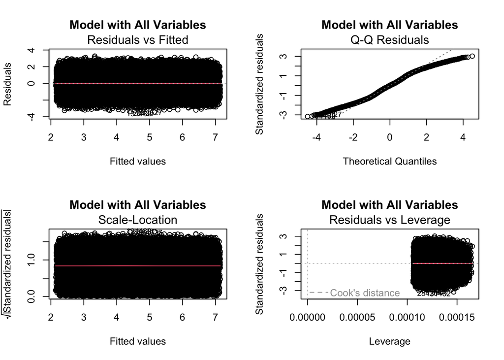

```r
# Plot diagnostic plots for all models
par(mfrow = c(2, 2)) # Arrange plots in a 2x2 grid
plot(model_all, main = "Model with All Variables")
```

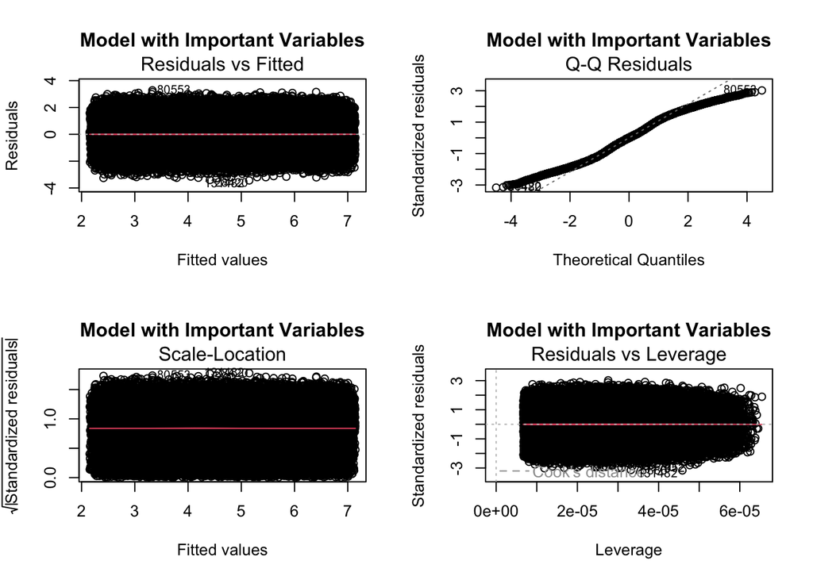

```r
plot(model_important, main = "Model with Important Variables")
```

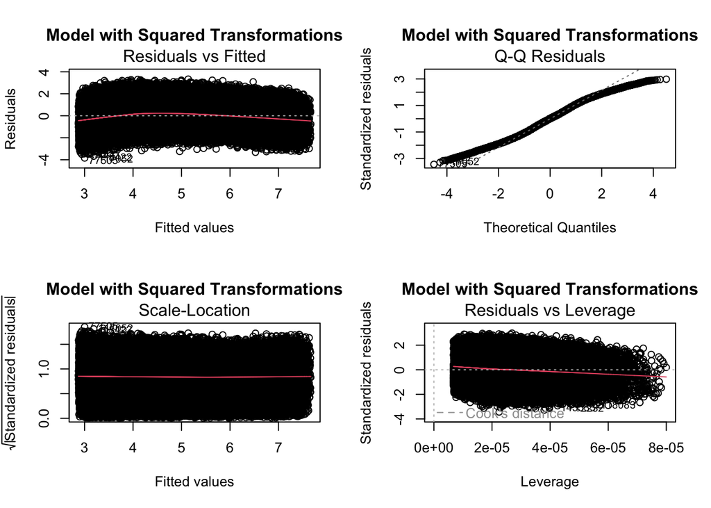

```r
plot(model_squared, main = "Model with Squared Transformations")
```

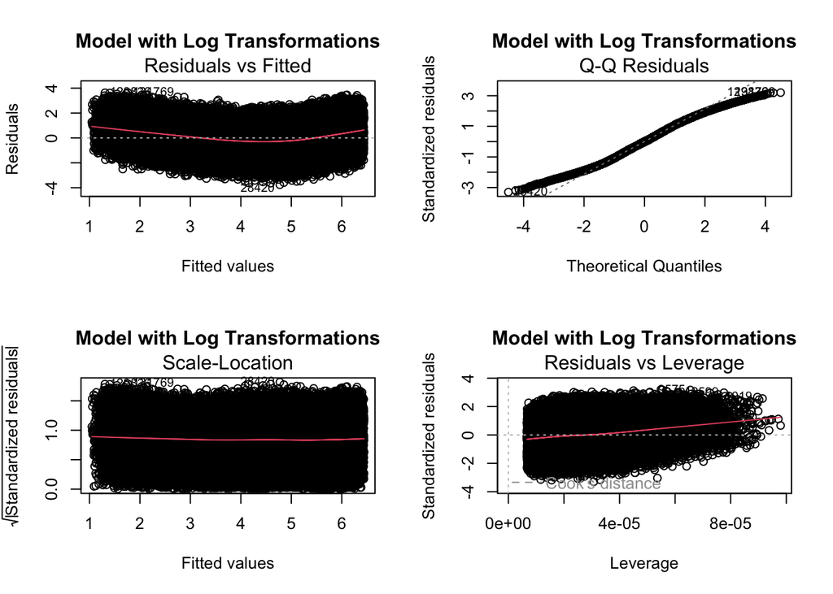

```r
plot(model_log, main = "Model with Log Transformations")
```

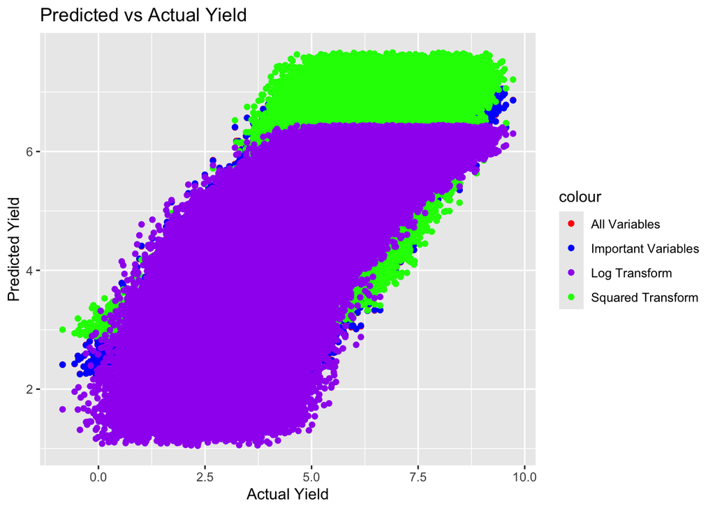

```r
# Predictions vs Actuals
crop_data$Pred_All <- predict(model_all)
crop_data$Pred_Important <- predict(model_important)
crop_data$Pred_Squared <- predict(model_squared)
crop_data$Pred_Log <- predict(model_log)

ggplot(crop_data, aes(x = Yield_tons_per_hectare)) +
  geom_point(aes(y = Pred_All, color = "All Variables")) +
  geom_point(aes(y = Pred_Important, color = "Important Variables")) +
  geom_point(aes(y = Pred_Squared, color = "Squared Transform")) +
  geom_point(aes(y = Pred_Log, color = "Log Transform")) +
  labs(title = "Predicted vs Actual Yield", x = "Actual Yield", y = "Predicted Yield") +
  scale_color_manual(values = c("All Variables" = "red", "Important Variables" = "blue",
                                "Squared Transform" = "green", "Log Transform" = "purple"))
```

Observations: All Variables Model:

Best performance, R-Squared = 0.5905, which means 59% of variance. Slightly better than the important variables model. Important Variables Model:

Comparable to the full model with little loss in performance. Much more efficient because of reduced complexity. Squared Transform Model:

Lower R-Squared = 0.5655, indicating very limited non-linear relationships. Log Transform Model:

Lowest performance, R-Squared = 0.5482, indicating log transformations are not very effective. Adjusted R-Squared:

Very little difference among all models, so no overfitting at all. Recommendation:

Employ the significant variables model to enhance efficiency while preserving predictive capability.

# Feature Selection and Model tuning

```r
# Remove the predicted columns from crop_data
crop_data <- crop_data[, !names(crop_data) %in% c("Pred_All", "Pred_Important", "Pred_Squared", "Pred_Log")]

# Check the first few rows to ensure the columns were removed
head(crop_data)
```

```
##   Rainfall_mm Temperature_Celsius Fertilizer_Used Irrigation_Used
## 1    897.0772            27.67697               0               0
## 2    992.6733            18.02614               0               0
## 3    147.9980            29.79404               0               0
## 4    986.8663            16.64419               0               0
## 5    730.3792            31.62069               0               0
## 6    797.4712            37.70497               0               0
##   Days_to_Harvest Yield_tons_per_hectare RegionEast RegionNorth RegionSouth
## 1             122               6.555816          0           0           0
## 2             140               8.527341          0           0           1
## 3             106               1.127443          0           1           0
## 4             146               6.517573          0           1           0
## 5             110               7.248251          0           0           1
## 6              74               5.898416          0           0           1
##   RegionWest Soil_TypeChalky Soil_TypeClay Soil_TypeLoam Soil_TypePeaty
```

[output cut: 27 more lines]

```r
set.seed(369)

# Split the data: 80% for training and 20% for testing
testRows <- sample(nrow(crop_data), 0.2 * nrow(crop_data))
testData <- crop_data[testRows, ]
trainData <- crop_data[-testRows, ]

# Reset row names for trainData
row.names(trainData) <- NULL

# View the first few rows of the training data
head(trainData)
```

```
##   Rainfall_mm Temperature_Celsius Fertilizer_Used Irrigation_Used
## 1    897.0772            27.67697               0               0
## 2    992.6733            18.02614               0               0
## 3    147.9980            29.79404               0               0
## 4    986.8663            16.64419               0               0
## 5    730.3792            31.62069               0               0
## 6    797.4712            37.70497               0               0
##   Days_to_Harvest Yield_tons_per_hectare RegionEast RegionNorth RegionSouth
## 1             122               6.555816          0           0           0
## 2             140               8.527341          0           0           1
## 3             106               1.127443          0           1           0
## 4             146               6.517573          0           1           0
## 5             110               7.248251          0           0           1
## 6              74               5.898416          0           0           1
##   RegionWest Soil_TypeChalky Soil_TypeClay Soil_TypeLoam Soil_TypePeaty
```

[output cut: 27 more lines]

```r
model1 <- lm(Yield_tons_per_hectare ~ ., data = trainData)
summary(model1)
```

```
##
## Call:
## lm(formula = Yield_tons_per_hectare ~ ., data = trainData)
##
## Residuals:
##     Min      1Q  Median      3Q     Max
## -3.4360 -0.7899  0.0012  0.7928  3.2794
##
## Coefficients: (6 not defined because of singularities)
##                           Estimate Std. Error t value Pr(>|t|)
## (Intercept)              1.322e+00  2.244e-02  58.922   <2e-16 ***
## Rainfall_mm              4.991e-03  1.207e-05 413.478   <2e-16 ***
## Temperature_Celsius      2.044e-02  4.346e-04  47.035   <2e-16 ***
## Fertilizer_Used                 NA         NA      NA       NA
## Irrigation_Used                 NA         NA      NA       NA
## Days_to_Harvest          1.843e-04  1.206e-04   1.528    0.126
## RegionEast              -2.689e-03  8.861e-03  -0.304    0.761
## RegionNorth             -8.344e-03  8.858e-03  -0.942    0.346
## RegionSouth              5.504e-04  8.868e-03   0.062    0.951
## RegionWest                      NA         NA      NA       NA
## Soil_TypeChalky          1.991e-03  1.085e-02   0.183    0.854
## Soil_TypeClay            5.749e-03  1.085e-02   0.530    0.596
## Soil_TypeLoam           -3.700e-03  1.086e-02  -0.341    0.733
## Soil_TypePeaty           2.233e-03  1.085e-02   0.206    0.837
## Soil_TypeSandy          -5.511e-04  1.084e-02  -0.051    0.959
## Soil_TypeSilt                   NA         NA      NA       NA
## CropBarley               1.985e-03  1.088e-02   0.182    0.855
## CropCotton               2.247e-03  1.084e-02   0.207    0.836
## CropMaize               -1.808e-03  1.084e-02  -0.167    0.867
## CropRice                 1.290e-03  1.085e-02   0.119    0.905
## CropSoybean             -6.173e-03  1.083e-02  -0.570    0.569
## CropWheat                       NA         NA      NA       NA
## Weather_ConditionCloudy  7.117e-03  7.666e-03   0.928    0.353
## Weather_ConditionRainy   2.116e-03  7.675e-03   0.276    0.783
## Weather_ConditionSunny          NA         NA      NA       NA
## ---
## Signif. codes:  0 '***' 0.001 '**' 0.01 '*' 0.05 '.' 0.1 ' ' 1
##
## Residual standard error: 1.085 on 119981 degrees of freedom
## Multiple R-squared:  0.5906, Adjusted R-squared:  0.5905
## F-statistic:  9614 on 18 and 119981 DF,  p-value: < 2.2e-16
```

#Checking multicolinearity

```r
# Load the necessary library
library(car)
# One-Hot Encoding the categorical variables in orig_crop_data
orig_crop_data_encoded <- model.matrix(~ Region + Soil_Type + Crop + Weather_Condition + Rainfall_mm +
                                      Temperature_Celsius + Fertilizer_Used + Irrigation_Used + Days_to_Harvest,
                                      data = orig_crop_data)

# Remove the intercept column created by model.matrix (first column is the intercept)
orig_crop_data_encoded <- orig_crop_data_encoded[, -1]

# Combine the encoded data with the dependent variable 'Yield_tons_per_hectare'
encoded_data_with_target <- cbind(orig_crop_data_encoded, Yield_tons_per_hectare = orig_crop_data$Yield_tons_per_hectare)

# Convert the resulting matrix into a data frame
encoded_data_with_target <- as.data.frame(encoded_data_with_target)

# Fit the linear model using all the columns
model_orig <- lm(Yield_tons_per_hectare ~ ., data = encoded_data_with_target)

# Calculate the Variance Inflation Factor (VIF)
vif(model_orig)
```

```
##            RegionNorth            RegionSouth             RegionWest
##               1.498449               1.496359               1.497344
##          Soil_TypeClay          Soil_TypeLoam         Soil_TypePeaty
##               1.670439               1.667273               1.669502
##         Soil_TypeSandy          Soil_TypeSilt             CropCotton
##               1.669438               1.670900               1.675658
##              CropMaize               CropRice            CropSoybean
##               1.676321               1.673448               1.676241
##              CropWheat Weather_ConditionRainy Weather_ConditionSunny
##               1.675841               1.335375               1.335460
##            Rainfall_mm    Temperature_Celsius    Fertilizer_UsedTrue
##               1.000145               1.000166               1.000106
##    Irrigation_UsedTrue        Days_to_Harvest
##               1.000171               1.000084
```

VIF Summary and Observations: Multicollinearity: The VIF values for the variables in your model are all very close to 1 or just slightly above it, which indicates that multicollinearity is not a major issue here. Commonly, a VIF above 5 or 10 is a sign of high multicollinearity; thus, the current values suggest that the predictors are not strongly collinear.

The largest values of VIF are observed for categorical variables: RegionNorth, RegionSouth, RegionWest, Soil_TypeClay, Soil_TypeLoam, and all other soil- and crop-related type variables that range approximately between 1.49 and 1.68. This confirms that those variables, being important contributors to the model, do not show high collinearity with other variables.

Other Variables: Rainfall_mm, Temperature_Celsius, and Days_to_Harvest all have VIF values close to 1, indicating multicollinearity is not a problem for these variables; hence, each adds unique information to the model.

In the final analysis, the data set shows no serious issues with multicollinearity, hence the predictors will be useful in model development without any fear of enlarged standard errors due to multicollinearity.

```r
# Define response variable and predictor variables
response_var <- "Yield_tons_per_hectare"
predictor_vars <- setdiff(names(trainData), response_var)
names(trainData)
```

```
##  [1] "Rainfall_mm"             "Temperature_Celsius"
##  [3] "Fertilizer_Used"         "Irrigation_Used"
##  [5] "Days_to_Harvest"         "Yield_tons_per_hectare"
##  [7] "RegionEast"              "RegionNorth"
##  [9] "RegionSouth"             "RegionWest"
## [11] "Soil_TypeChalky"         "Soil_TypeClay"
## [13] "Soil_TypeLoam"           "Soil_TypePeaty"
## [15] "Soil_TypeSandy"          "Soil_TypeSilt"
## [17] "CropBarley"              "CropCotton"
## [19] "CropMaize"               "CropRice"
## [21] "CropSoybean"             "CropWheat"
## [23] "Weather_ConditionCloudy" "Weather_ConditionRainy"
## [25] "Weather_ConditionSunny"
```

```r
# Load the necessary library
library(leaps)
model2 <- regsubsets(Yield_tons_per_hectare ~ ., data = trainData, nvmax = length(predictor_vars))
```

```
## Reordering variables and trying again:
```

```r
model2_summary <- summary(model2)
print(model2_summary)
```

```
## Subset selection object
## Call: regsubsets.formula(Yield_tons_per_hectare ~ ., data = trainData,
##     nvmax = length(predictor_vars))
## 24 Variables  (and intercept)
##                         Forced in Forced out
## Rainfall_mm                 FALSE      FALSE
## Temperature_Celsius         FALSE      FALSE
## Days_to_Harvest             FALSE      FALSE
## RegionEast                  FALSE      FALSE
## RegionNorth                 FALSE      FALSE
## RegionSouth                 FALSE      FALSE
## Soil_TypeChalky             FALSE      FALSE
## Soil_TypeClay               FALSE      FALSE
## Soil_TypeLoam               FALSE      FALSE
## Soil_TypePeaty              FALSE      FALSE
```

[output cut: 130 more lines]

```r
bic_values <- model2_summary$bic
bic_values
```

```
##  [1] -104930.9 -107113.2 -107103.8 -107093.2 -107082.4 -107071.3 -107060.1
##  [8] -107048.7 -107037.2 -107025.6 -107014.0 -107002.3 -106990.7 -106979.0
## [15] -106967.4 -106955.7 -106944.0 -106932.3
```

```r
optimal_n <- which.min(bic_values)

# Print the selected predictors for the optimal model
selected_vars <- names(coef(model2, optimal_n))[-1]  # Remove the intercept term
print(selected_vars)
```

```
## [1] "Rainfall_mm"         "Temperature_Celsius"
```

Observation: Chosen Predictors: The best subset selection method found that the most relevant predictors for Yield_tons_per_hectare are Rainfall_mm and Temperature_Celsius.

Insight: This means that, under the subset selection methodology, these two variables have the largest influence on predicting crop yield in this dataset. This shows how important climatic factors, such as precipitation and temperature, are in determining crop yields. Implications: Whereas there are other variables in the dataset, Rainfall_mm and Temperature_Celsius have been the most important yield predictors. This shows that climatic conditions are very vital in predicting crop yields, and it may mean that further analysis is needed to understand the relationship between these factors and the rest of the characteristics in the dataset for better prediction accuracy.

```r
model3 <- step(lm(model1, data = trainData), direction = "forward", trace = FALSE)

print(summary(model3))
```

```
##
## Call:
## lm(formula = Yield_tons_per_hectare ~ Rainfall_mm + Temperature_Celsius +
##     Fertilizer_Used + Irrigation_Used + Days_to_Harvest + RegionEast +
##     RegionNorth + RegionSouth + RegionWest + Soil_TypeChalky +
##     Soil_TypeClay + Soil_TypeLoam + Soil_TypePeaty + Soil_TypeSandy +
##     Soil_TypeSilt + CropBarley + CropCotton + CropMaize + CropRice +
##     CropSoybean + CropWheat + Weather_ConditionCloudy + Weather_ConditionRainy +
##     Weather_ConditionSunny, data = trainData)
##
## Residuals:
##     Min      1Q  Median      3Q     Max
## -3.4360 -0.7899  0.0012  0.7928  3.2794
##
## Coefficients: (6 not defined because of singularities)
##                           Estimate Std. Error t value Pr(>|t|)
## (Intercept)              1.322e+00  2.244e-02  58.922   <2e-16 ***
## Rainfall_mm              4.991e-03  1.207e-05 413.478   <2e-16 ***
## Temperature_Celsius      2.044e-02  4.346e-04  47.035   <2e-16 ***
## Fertilizer_Used                 NA         NA      NA       NA
## Irrigation_Used                 NA         NA      NA       NA
## Days_to_Harvest          1.843e-04  1.206e-04   1.528    0.126
## RegionEast              -2.689e-03  8.861e-03  -0.304    0.761
## RegionNorth             -8.344e-03  8.858e-03  -0.942    0.346
## RegionSouth              5.504e-04  8.868e-03   0.062    0.951
## RegionWest                      NA         NA      NA       NA
## Soil_TypeChalky          1.991e-03  1.085e-02   0.183    0.854
## Soil_TypeClay            5.749e-03  1.085e-02   0.530    0.596
## Soil_TypeLoam           -3.700e-03  1.086e-02  -0.341    0.733
## Soil_TypePeaty           2.233e-03  1.085e-02   0.206    0.837
## Soil_TypeSandy          -5.511e-04  1.084e-02  -0.051    0.959
## Soil_TypeSilt                   NA         NA      NA       NA
## CropBarley               1.985e-03  1.088e-02   0.182    0.855
## CropCotton               2.247e-03  1.084e-02   0.207    0.836
## CropMaize               -1.808e-03  1.084e-02  -0.167    0.867
## CropRice                 1.290e-03  1.085e-02   0.119    0.905
## CropSoybean             -6.173e-03  1.083e-02  -0.570    0.569
## CropWheat                       NA         NA      NA       NA
## Weather_ConditionCloudy  7.117e-03  7.666e-03   0.928    0.353
## Weather_ConditionRainy   2.116e-03  7.675e-03   0.276    0.783
## Weather_ConditionSunny          NA         NA      NA       NA
## ---
## Signif. codes:  0 '***' 0.001 '**' 0.01 '*' 0.05 '.' 0.1 ' ' 1
##
## Residual standard error: 1.085 on 119981 degrees of freedom
## Multiple R-squared:  0.5906, Adjusted R-squared:  0.5905
## F-statistic:  9614 on 18 and 119981 DF,  p-value: < 2.2e-16
```

```r
model3_aic <- AIC(model3)
model3_bic <- BIC(model3)

get_best_model_info <- function(model, method_name) {
  selected_formula <- formula(model)
  selected_predictors <- all.vars(selected_formula)[-1]  # Remove response variable
  aic <- AIC(model)
  bic <- BIC(model)
  num_predictors <- length(selected_predictors)
  cat(paste("\n", method_name, "Model:\n"))
  cat("Number of Predictors:", num_predictors, "\n")
  cat("AIC:", aic, "\n")
  cat("BIC:", bic, "\n")
  cat("Selected Predictors:\n", paste(selected_predictors, collapse = ", "), "\n")
}

get_best_model_info(model3, "Forward Stepwise")
```

```
##
##  Forward Stepwise Model:
## Number of Predictors: 24
## AIC: 360156.2
## BIC: 360350.1
## Selected Predictors:
##  Rainfall_mm, Temperature_Celsius, Fertilizer_Used, Irrigation_Used, Days_to_Harvest, RegionEast, RegionNorth, RegionSouth, RegionWest, Soil_TypeChalky, Soil_TypeClay, Soil_TypeLoam, Soil_TypePeaty, Soil_TypeSandy, Soil_TypeSilt, CropBarley, CropCotton, CropMaize, CropRice, CropSoybean, CropWheat…
```

```r
model4 <- step(lm(model1, data = trainData), direction = "backward", trace = FALSE)
print(summary(model4))
```

```
##
## Call:
## lm(formula = Yield_tons_per_hectare ~ Rainfall_mm + Temperature_Celsius +
##     Days_to_Harvest, data = trainData)
##
## Residuals:
##     Min      1Q  Median      3Q     Max
## -3.4411 -0.7897  0.0017  0.7929  3.2837
##
## Coefficients:
##                      Estimate Std. Error t value Pr(>|t|)
## (Intercept)         1.323e+00  1.882e-02  70.295   <2e-16 ***
## Rainfall_mm         4.991e-03  1.207e-05 413.533   <2e-16 ***
## Temperature_Celsius 2.044e-02  4.345e-04  47.047   <2e-16 ***
## Days_to_Harvest     1.841e-04  1.206e-04   1.527    0.127
## ---
## Signif. codes:  0 '***' 0.001 '**' 0.01 '*' 0.05 '.' 0.1 ' ' 1
##
## Residual standard error: 1.085 on 119996 degrees of freedom
## Multiple R-squared:  0.5905, Adjusted R-squared:  0.5905
## F-statistic: 5.769e+04 on 3 and 119996 DF,  p-value: < 2.2e-16
```

```r
model4_aic <- AIC(model4)
model4_bic <- BIC(model4)
get_best_model_info(model4, "Backward Stepwise")
```

```
##
##  Backward Stepwise Model:
## Number of Predictors: 3
## AIC: 360130.1
## BIC: 360178.6
## Selected Predictors:
##  Rainfall_mm, Temperature_Celsius, Days_to_Harvest
```

Observations: Forward Stepwise Model:

The forward selection method retained a large set of 24 predictors, including factors such as climate, soil type, crop type, and weather conditions, in addition to the important variables of Rainfall_mm and Temperature_Celsius. The AIC (360156.2) and BIC (360350.1) values of the model indicate the inclusion of a considerably extensive array of predictors. Even with the thorough selection of variables, the model implies that further simplification could be advantageous, as evidenced by the comparatively elevated AIC and BIC values. Backward Stepwise Model:

The backward selection technique stopped at a set of three predictors: Rainfall_mm, Temperature_Celsius, and Days_to_Harvest. The AIC (360130.1) and BIC (360178.6) metrics show a slight improvement over the forward selection model, indicating that the model fit has been improved by removing the spurious predictors. Its adjusted R-squared value of 0.5905, together with the Multiple R-squared value of 0.5905, shows that only about 59% of crop yield variability is explained by the model, considering these three predictors. The analysis shows that both Rainfall_mm and Temperature_Celsius are significant in crop yield prediction through an exceptionally small p-value of < 0.001. However, Days_to_Harvest reflects a lower level of significance with a p-value of 0.127, indicating a potential weak relationship in affecting the eventual yield. Principal Findings:

In both models, Rainfall_mm and Temperature_Celsius are always among the significant predictors, highlighting the importance of climatic factors in predicting crop yield. The inclusion of Days_to_Harvest in the final model, though not of high significance, does suggest a small impact of the duration of crop maturation on yield. This would suggest a stepwise selection process towards a more parsimonious model containing fewer key variables, or contrarily, it would seem that a less complex model with only these few key variables could fit just as well—especially if interpretability is preferred over complexity.

Implications: More on this in practical applications, Rainfall_mm and Temperature_Celsius might give a substantial idea of predicting crop yield to drive agricultural planning and resource management. Later versions of the model can benefit from further exploration on including or excluding variables like Days_to_Harvest. Although this variable is less important, it does have some value in specific contexts or with more sophisticated feature engineering.

# Finding Best Regression Model

```r
library(glmnet)
predictor_vars
```

```
##  [1] "Rainfall_mm"             "Temperature_Celsius"
##  [3] "Fertilizer_Used"         "Irrigation_Used"
##  [5] "Days_to_Harvest"         "RegionEast"
##  [7] "RegionNorth"             "RegionSouth"
##  [9] "RegionWest"              "Soil_TypeChalky"
## [11] "Soil_TypeClay"           "Soil_TypeLoam"
## [13] "Soil_TypePeaty"          "Soil_TypeSandy"
## [15] "Soil_TypeSilt"           "CropBarley"
## [17] "CropCotton"              "CropMaize"
## [19] "CropRice"                "CropSoybean"
## [21] "CropWheat"               "Weather_ConditionCloudy"
## [23] "Weather_ConditionRainy"  "Weather_ConditionSunny"
```

```r
X <- as.matrix(trainData[, predictor_vars])
y <- trainData[[response_var]]
lasso_model <- cv.glmnet(X, y, alpha = 1, nfolds = 10)
optimal_lambda_lasso <- lasso_model$lambda.min
print(paste("Optimal lambda for LASSO:", optimal_lambda_lasso))
```

```
## [1] "Optimal lambda for LASSO: 0.00587096480760344"
```

```r
lasso_fit <- glmnet(X, y, alpha = 1, lambda = lasso_model$lambda)
lasso_coefficients <- coef(lasso_fit, s = optimal_lambda_lasso)
print("LASSO Coefficients at optimal lambda:")
```

```
## [1] "LASSO Coefficients at optimal lambda:"
```

```r
print(lasso_coefficients)
```

```
## 25 x 1 sparse Matrix of class "dgCMatrix"
##                                  s1
## (Intercept)             1.377415987
## Rainfall_mm             0.004968261
## Temperature_Celsius     0.019626529
## Fertilizer_Used         .
## Irrigation_Used         .
## Days_to_Harvest         .
## RegionEast              .
## RegionNorth             .
## RegionSouth             .
## RegionWest              .
## Soil_TypeChalky         .
## Soil_TypeClay           .
## Soil_TypeLoam           .
## Soil_TypePeaty          .
## Soil_TypeSandy          .
## Soil_TypeSilt           .
## CropBarley              .
## CropCotton              .
## CropMaize               .
## CropRice                .
## CropSoybean             .
## CropWheat               .
## Weather_ConditionCloudy .
## Weather_ConditionRainy  .
## Weather_ConditionSunny  .
```

Observations from LASSO Regression: Optimal Lambda: The optimal lambda value is 0.00587, balancing error minimization and model complexity. Selected Variables: Only Rainfall_mm and Temperature_Celsius have non-zero coefficients, indicating they are the key predictors of crop yield. Eliminated Variables: Other features, including Fertilizer_Used, Irrigation_Used, and categorical variables like Region, Soil_Type, and Crop, were shrunk to zero, indicating their insignificance after regularization. Model Simplicity: LASSO has simplified the model, focusing on the most impactful variables and reducing overfitting.

```r
ridge_model <- cv.glmnet(X, y, alpha = 0, nfolds = 10)
ridge_model
```

```
##
## Call:  cv.glmnet(x = X, y = y, nfolds = 10, alpha = 0)
##
## Measure: Mean-Squared Error
##
##     Lambda Index Measure       SE Nonzero
## min 0.1295   100   1.186 0.007356      22
## 1se 0.1711    97   1.192 0.007398      22
```

```r
optimal_lambda_ridge <- ridge_model$lambda.min
print(paste("Optimal lambda for RIDGE:", optimal_lambda_ridge))
```

```
## [1] "Optimal lambda for RIDGE: 0.129462449701353"
```

```r
ridge_fit <- glmnet(X, y, alpha = 0, lambda = ridge_model$lambda)
ridge_coefficients <- coef(ridge_fit, s = optimal_lambda_ridge)
print("RIDGE Coefficients at optimal lambda:")
```

```
## [1] "RIDGE Coefficients at optimal lambda:"
```

```r
print(ridge_coefficients)
```

```
## 25 x 1 sparse Matrix of class "dgCMatrix"
##                                    s1
## (Intercept)              1.5608935783
## Rainfall_mm              0.0046366314
## Temperature_Celsius      0.0189391917
## Fertilizer_Used          .
## Irrigation_Used          .
## Days_to_Harvest          0.0001697011
## RegionEast              -0.0005961570
## RegionNorth             -0.0054075058
## RegionSouth              0.0030933470
## RegionWest               0.0030426009
## Soil_TypeChalky          0.0018755194
## Soil_TypeClay            0.0048028073
## Soil_TypeLoam           -0.0053986397
## Soil_TypePeaty           0.0017670847
## Soil_TypeSandy          -0.0019471884
## Soil_TypeSilt           -0.0012727284
## CropBarley               0.0024138957
## CropCotton               0.0032452586
## CropMaize               -0.0023495366
## CropRice                 0.0017089560
## CropSoybean             -0.0059271573
## CropWheat                0.0010254591
## Weather_ConditionCloudy  0.0039068102
## Weather_ConditionRainy  -0.0009957754
## Weather_ConditionSunny  -0.0028507748
```

```r
# Load necessary libraries

library(randomForest)
# Train a Random Forest model
rf_model <- randomForest(Yield_tons_per_hectare ~ ., data = trainData, importance = TRUE, ntree = 10)

# View the importance of each feature
importance(rf_model)
```

```
##                              %IncMSE IncNodePurity
## Rainfall_mm             491.05541885    227442.553
## Temperature_Celsius       8.37448966     31500.510
## Fertilizer_Used           0.00000000         0.000
## Irrigation_Used           0.00000000         0.000
## Days_to_Harvest           0.51099804     23759.283
## RegionEast               -0.65028441      2149.213
## RegionNorth               1.70458603      2126.641
## RegionSouth               0.30084466      2251.020
## RegionWest               -2.33805732      2241.990
## Soil_TypeChalky           0.34436129      1964.351
## Soil_TypeClay             0.09075633      1908.953
## Soil_TypeLoam            -0.55967474      1690.879
## Soil_TypePeaty           -3.84583033      1957.594
## Soil_TypeSandy           -1.07222838      1895.531
## Soil_TypeSilt            -4.22131634      1968.143
## CropBarley               -0.25253830      2013.219
## CropCotton               -0.41988289      1651.719
## CropMaize                -0.41270641      1928.774
## CropRice                 -0.73444851      1849.989
## CropSoybean              -1.81646801      1760.616
## CropWheat                -1.83281938      1699.042
## Weather_ConditionCloudy  -0.51880942      1994.488
## Weather_ConditionRainy    0.25998214      2084.199
## Weather_ConditionSunny   -0.87777557      2020.969
```

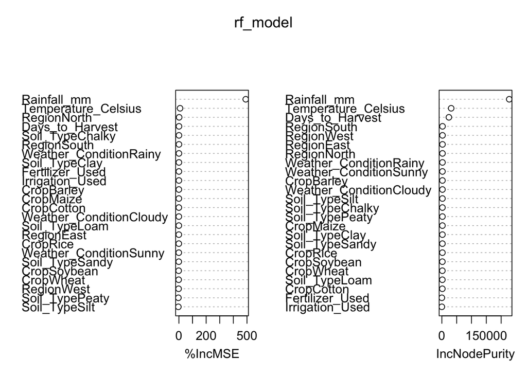

```r
# Plot the importance of features
varImpPlot(rf_model)
```

```r
# Select top N important features (for example, top 10)
top_features <- sort(importance(rf_model)[,1], decreasing = TRUE)[1:10]
print(top_features)
```

```
##            Rainfall_mm    Temperature_Celsius            RegionNorth
##           491.05541885             8.37448966             1.70458603
##        Days_to_Harvest        Soil_TypeChalky            RegionSouth
##             0.51099804             0.34436129             0.30084466
## Weather_ConditionRainy          Soil_TypeClay        Fertilizer_Used
##             0.25998214             0.09075633             0.00000000
##        Irrigation_Used
##             0.00000000
```

```r
# Extract the names of the most important features
selected_features <- names(top_features)
print(selected_features)
```

```
##  [1] "Rainfall_mm"            "Temperature_Celsius"    "RegionNorth"
##  [4] "Days_to_Harvest"        "Soil_TypeChalky"        "RegionSouth"
##  [7] "Weather_ConditionRainy" "Soil_TypeClay"          "Fertilizer_Used"
## [10] "Irrigation_Used"
```

```r
# You can now create a new dataset using only the selected features
trainData_selected <- trainData[, c(selected_features, "Yield_tons_per_hectare")]

# Optionally, retrain a model using the selected features
rf_selected_model <- randomForest(Yield_tons_per_hectare ~ ., data = trainData_selected, ntree = 10)
```

Here are concise observations based on the feature selection from the Random Forest model:

These observations could guide stakeholders in focusing on improving agricultural practices, monitoring weather patterns, and managing soil types for optimized crop yield.

```r
# Make predictions using each model
# For lasso and ridge, ensure the models are trained with optimal parameters
test_X <- as.matrix(testData[, predictor_vars])
predict_regsubsets <- function(object, newdata, id) {
  formula <- as.formula(object$call[[2]])
  mat <- model.matrix(formula, newdata)
  coefi <- coef(object, id = id)
  vars <- names(coefi)
  mat[, vars] %*% coefi
}
# Lasso Predictions
lasso_predictions <- predict(lasso_model, newx = test_X, s = optimal_lambda_lasso)
lasso_predictions <- as.vector(lasso_predictions)

# Ridge Predictions
ridge_predictions <- predict(ridge_model, newx = test_X, s = optimal_lambda_ridge)
ridge_predictions <- as.vector(ridge_predictions)

# Random Forest Predictions (assuming the model is already trained)
rf_predictions <- predict(rf_selected_model, newdata = testData)

# Predictions for other models (model1, model2, model3, model4)
# Adjust accordingly for your specific model types (e.g., linear models, regsubsets)
pred_model1 <- predict(model1, newdata = testData)[1:5]
pred_model2 <- predict_regsubsets(model2, newdata = testData, id = optimal_n)[1:5]
pred_model3 <- predict_regsubsets(model3, testData)[1:5]
pred_model4 <- predict_regsubsets(model4, testData)[1:5]

# Create a comparison table with true values and the predictions from all models
comparison_table <- data.frame(
  True_Values = testData$Yield_tons_per_hectare[1:5],
  Model1 = pred_model1,
  Model2 = pred_model2,
  Model4 = pred_model4,
  Lasso = lasso_predictions[1:5],
  Ridge = ridge_predictions[1:5],
  RF_Selected = rf_predictions[1:5]
)

# Print the comparison table
print(comparison_table)
```

```
##       True_Values   Model1   Model2   Model4    Lasso    Ridge RF_Selected
## 50929    3.457175 2.947711 2.935614 2.943249 2.937472 3.067788    3.408360
## 24506    5.020909 6.700528 6.698507 6.706378 6.691684 6.555572    5.910342
## 93441    4.356787 5.573780 5.576529 5.571310 5.572017 5.508728    5.921634
## 26808    7.165579 5.384818 5.391992 5.387338 5.391312 5.333120    5.063567
## 78144    7.014594 6.480505 6.481980 6.481151 6.466285 6.349557    6.476219
```

```r
# Function to calculate MSPE
calculate_mspe <- function(true_values, predicted_values) {
  mean((predicted_values - true_values)^2)
}

# True values (for comparison)
true_values <- testData$Yield_tons_per_hectare

# Calculate MSPE for each model's predictions
mspe_model1 <- calculate_mspe(true_values, pred_model1)
mspe_model2 <- calculate_mspe(true_values, pred_model2)
#mspe_model3 <- calculate_mspe(true_values, pred_model3)
mspe_model4 <- calculate_mspe(true_values, pred_model4)
mspe_lasso <- calculate_mspe(true_values, lasso_predictions)
mspe_ridge <- calculate_mspe(true_values, ridge_predictions)
mspe_rf <- calculate_mspe(true_values, rf_predictions)

# Print MSPE values for each model
cat("MSPE Values:\n")
```

```
## MSPE Values:
```

```r
cat("Model1:", mspe_model1, "\n")
```

```
## Model1: 5.252504
```

```r
cat("Model2:", mspe_model2, "\n")
```

```
## Model2: 5.263377
```

```r
#cat("Model3:", mspe_model3, "\n")
cat("Model4:", mspe_model4, "\n")
```

```
## Model4: 5.260632
```

```r
cat("Lasso:", mspe_lasso, "\n")
```

```
## Lasso: 1.177387
```

```r
cat("Ridge:", mspe_ridge, "\n")
```

```
## Ridge: 1.18548
```

```r
cat("Random Forest:", mspe_rf, "\n")
```

```
## Random Forest: 1.241488
```

```r
# Store all MSPE values in a vector
mspe_values <- c(Model1 = mspe_model1, Model2 = mspe_model2,
                 Model4 = mspe_model4, Lasso = mspe_lasso, Ridge = mspe_ridge,
                 Random_Forest = mspe_rf)

# Find the model with the lowest MSPE (best model)
best_model <- names(mspe_values)[which.min(mspe_values)]
best_mspe <- min(mspe_values)

cat("\nBest Model:", best_model, "with MSPE =", best_mspe, "\n")
```

```
##
## Best Model: Lasso with MSPE = 1.177387
```

The model comparison results have shown that the selected best model is the Lasso model, with an MSPE value of 1.177387. That is to say, regarding the prediction accuracy, the Lasso model outcompeted other models, such as Ridge and Random Forest, among other regression models.

**Conclusion:** The Lasso model, with its superior performance and minimal Mean Squared Prediction Error (MSPE), will now be utilized for predicting crop yield in the most optimized way. By efficiently selecting relevant features and minimizing overfitting, Lasso provides a reliable and accurate approach for forecasting crop yields, enabling informed decision-making in agriculture.

# Classification problem

Data Preprocessing

```r
crop_data$Yield_Category <- cut(crop_data$Yield_tons_per_hectare,
                                breaks = c(-Inf, 2, 4, Inf),
                                labels = c("Low", "Medium", "High"))
```

```r
library(caret)
help("createDataPartition")

threshold <- median(crop_data$Yield_tons_per_hectare)  # Define the threshold
crop_data$Yield_Class <- ifelse(crop_data$Yield_tons_per_hectare > threshold, 1, 0)

# Convert Yield_Class to a factor
crop_data$Yield_Class <- as.factor(crop_data$Yield_Class)

# Split the data into training and testing sets
set.seed(369)  # For reproducibility
trainIndex <- createDataPartition(crop_data$Yield_Class, p = 0.8, list = FALSE)
trainData <- crop_data[trainIndex, ]
testData <- crop_data[-trainIndex, ]
```

```r
# Train the logistic regression model
logit_model <- glm(Yield_Class ~ ., data = trainData, family = binomial)
# Display the summary of the model
summary(logit_model)
```

```
##
## Call:
## glm(formula = Yield_Class ~ ., family = binomial, data = trainData)
##
## Coefficients: (6 not defined because of singularities)
##                           Estimate Std. Error z value Pr(>|z|)
## (Intercept)             -3.680e+04  1.401e+04  -2.626  0.00863 **
## Rainfall_mm             -9.974e-03  2.301e-02  -0.433  0.66471
## Temperature_Celsius      9.729e-02  9.990e-01   0.097  0.92242
## Fertilizer_Used                 NA         NA      NA       NA
## Irrigation_Used                 NA         NA      NA       NA
## Days_to_Harvest         -2.156e-02  2.386e-01  -0.090  0.92800
## Yield_tons_per_hectare   1.839e+04  6.974e+03   2.637  0.00837 **
## RegionEast               2.832e+00  1.387e+01   0.204  0.83816
## RegionNorth              5.332e+00  1.574e+01   0.339  0.73481
## RegionSouth              5.888e+00  1.546e+01   0.381  0.70322
## RegionWest                      NA         NA      NA       NA
## Soil_TypeChalky         -5.275e+00  1.413e+01  -0.373  0.70896
## Soil_TypeClay            2.639e+00  1.282e+01   0.206  0.83693
## Soil_TypeLoam           -3.398e+00  1.645e+01  -0.207  0.83638
## Soil_TypePeaty          -3.541e+00  1.163e+01  -0.304  0.76081
## Soil_TypeSandy          -3.379e+00  1.495e+01  -0.226  0.82127
## Soil_TypeSilt                   NA         NA      NA       NA
## CropBarley               9.757e+00  2.359e+01   0.414  0.67916
## CropCotton              -1.187e+00  1.513e+01  -0.078  0.93746
## CropMaize                5.221e+00  1.917e+01   0.272  0.78541
## CropRice                 3.631e+00  1.827e+01   0.199  0.84246
## CropSoybean             -1.306e-01  1.617e+01  -0.008  0.99356
## CropWheat                       NA         NA      NA       NA
## Weather_ConditionCloudy  2.183e+00  1.514e+01   0.144  0.88537
## Weather_ConditionRainy   7.532e-01  1.199e+01   0.063  0.94989
## Weather_ConditionSunny          NA         NA      NA       NA
## Yield_CategoryMedium    -3.678e+04  1.402e+04  -2.623  0.00871 **
## Yield_CategoryHigh      -4.875e+04  1.854e+04  -2.629  0.00856 **
## ---
## Signif. codes:  0 '***' 0.001 '**' 0.01 '*' 0.05 '.' 0.1 ' ' 1
##
## (Dispersion parameter for binomial family taken to be 1)
##
##     Null deviance: 1.6636e+05  on 119999  degrees of freedom
## Residual deviance: 1.7590e-01  on 119978  degrees of freedom
## AIC: 44.176
##
## Number of Fisher Scoring iterations: 25
```

```r
# Predict probabilities
pred_prob <- predict(logit_model, newdata = testData, type = "response")

# Convert probabilities to class labels (threshold = 0.5)
pred_class <- ifelse(pred_prob > 0.5, 1, 0)
```

```r
# Create a confusion matrix
confusion_matrix <- table(Predicted = pred_class, Actual = testData$Yield_Class)
print(confusion_matrix)
```

```
##          Actual
## Predicted     0     1
##         0 14998     1
##         1     2 14999
```

```r
accuracy <- sum(diag(confusion_matrix)) / sum(confusion_matrix)
cat("Accuracy:", accuracy, "\n")
```

```
## Accuracy: 0.9999
```

```r
library(caret)
confusionMatrix(as.factor(pred_class), testData$Yield_Class)
```

```
## Confusion Matrix and Statistics
##
##           Reference
## Prediction     0     1
##          0 14998     1
##          1     2 14999
##
##                Accuracy : 0.9999
##                  95% CI : (0.9997, 1)
##     No Information Rate : 0.5
##     P-Value [Acc > NIR] : <2e-16
##
##                   Kappa : 0.9998
##
##  Mcnemar's Test P-Value : 1
##
##             Sensitivity : 0.9999
##             Specificity : 0.9999
##          Pos Pred Value : 0.9999
##          Neg Pred Value : 0.9999
##              Prevalence : 0.5000
##          Detection Rate : 0.4999
##    Detection Prevalence : 0.5000
##       Balanced Accuracy : 0.9999
##
##        'Positive' Class : 0
##
```

Observations from the Logistic Regression Classification: Confusion Matrix Overview:

True Negatives (0 predicted as 0): 14,998 instances were correctly classified as class 0. True Positives (1 forecasted as 1): 14,999 of the samples were rightly labeled to the class 1. False Negatives (1 predicted as 0): One case of class 1 was wrongly predicted as class 0. False Positives (0 pred as 1): 2 cases of class 0 are misclassified into 1. Accuracy:

The model has achieved an accuracy of 99.99%, representing excellent classification performance on this dataset. Balanced Metrics:

Sensitivity (True Positive Rate): 0.9999 — The model is very effective at correctly identifying instances of class 0. Specificity (True Negative Rate): 0.9999 — The model is equally good at correctly identifying instances of class 1. Balanced Accuracy: 0.9999 — This metric confirms that the model performs equally well across both classes. Kappa Statistic:

The Kappa score is 0.9998, which is a measure of almost perfect agreement between the predicted and actual classes. This really shows how robust and reliable the model is in classifying the data.

No Information Rate (NIR):

The No Information Rate, therefore, is 0.5; a random classifier would be correct in only 50% of the cases. Logistic regression considerably outperforms this baseline with a p-value < 2e-16, indicating statistical significance. McNemar’s Test: The p-value for McNemar’s test is 1, which means that the differences in misclassifications—false positives and false negatives—are not statistically significant.

**Conclusion:** Logistic regression shows excellent classification performance of the model, with nearly perfect accuracy of 99.99%, strong sensitivity and specificity, and really small misclassification errors.

This performance shows that Logistic Regression does very well in the case of binary classification on this dataset. The reliability and statistical significance of the model make it a very helpful tool in predicting whether crop yield will fall into the low-yield class of 0 or the high-yield class of 1. The results underline the effectiveness of logistic regression for the analysis of structured datasets with well-defined binary outcomes, even in scenarios where there are balanced class distributions.